# Intra-SIA Monitoring: Vaccine Vial Storage and VVM

Draft Analysis of APMIS Data

SIAs in the past 12 months, as of August 27, 2024

## Introduction

This report summarises key indicators of vaccine temperature management, based on data collected and reported by intra-campaign monitors. These data are collected during supervision visits to vaccination teams, and are recorded simply as ‘yes’ or ‘no’ based on the monitor’s observations during the supervision visit.

The questions asked by monitors during superivison visits vary based on the vaccination team’s modality: House-to-House (H2H) or Mosque-to-Mosque/Site-to-Site (M2M/S2S). Therefore, the indicators are summarised separately for each modality.

Indicators summarised in this report include the following:

- H2H Teams:
  - Based on observation of Vaccine Vial Monitor (VVM), vaccine is usable.
  - OPV vials are kept dry
- M2M/S2S Teams:
  - At least one vaccine vial with VVM is in stage not optimal for use
  - OPV vials are kept dry
  - Team has correct knowledge about VVM
  - Team has vaccine carrier with frozen ice-packs

This report includes data reported in APMIS from all SIAs conducted in the past 12 months, including the following SIAs: Sep NID 2023, Oct SNID 2023, Nov SNID 2023, Dec SNID 2023, Jan SNID 2024, Feb SNID 2024, Apr NID 2024, Jun NID 2024, Jul SNID 2024 and Aug CR 2024

*All percentages represent the number of vaccination team supervision visits where the supervisor responded ‘Yes’ to the question, divided by the number of team supervision visits where the question was responded to.*

## Summary of most recent SIA: Aug CR 2024

In the Aug CR 2024 SIA, the indicators were as follows for each included region:

| Indicator | Overall | South Region | West Region |
| --- | --- | --- | --- |
| H2H: Based on observation of VVM, vaccine is usable | 61% (2,111/3,471) | 38% (840/2,197) | 100% (1,271/1,274) |
| H2H: OPV vials are kept dry | 97% (3,368/3,471) | 97% (2,121/2,197) | 98% (1,247/1,274) |
| M2M/S2S: At least one vaccine vial with VVM is in stage not optimal for use | 2% (10/444) | 2% (7/433) | 27% (3/11) |
| M2M/S2S: OPV vials are kept dry | 100% (442/444) | 100% (431/433) | 100% (11/11) |
| M2M/S2S: Team has correct knowledge about VVM | 100% (442/444) | 100% (431/433) | 100% (11/11) |
| M2M/S2S: Team has vaccine carrier with frozen ice-packs | 99% (441/444) | 100% (433/433) | 73% (8/11) |

## Summary of Indicators Across SIAs, Overall and by Region

### Overall

| Indicator | Sep NID 2023 | Oct SNID 2023 | Nov SNID 2023 | Dec SNID 2023 | Jan SNID 2024 | Feb SNID 2024 | Apr NID 2024 | Jun NID 2024 | Jul SNID 2024 | Aug CR 2024 |
| --- | --- | --- | --- | --- | --- | --- | --- | --- | --- | --- |
| H2H: Based on observation of VVM, vaccine is usable | 90% (3,272/3,646) | 92% (4,765/5,169) | 93% (4,531/4,877) | 91% (4,407/4,823) | 87% (2,907/3,338) | 90% (3,176/3,513) | 94% (6,260/6,659) | 93% (5,778/6,244) | 81% (5,249/6,513) | 61% (2,111/3,471) |
| H2H: OPV vials are kept dry | 99% (3,615/3,646) | 99% (5,128/5,169) | 99% (4,848/4,877) | 99% (4,791/4,823) | 99% (3,299/3,338) | 99% (3,488/3,513) | 99% (6,590/6,659) | 99% (6,186/6,244) | 99% (6,421/6,513) | 97% (3,368/3,471) |
| M2M/S2S: At least one vaccine vial with VVM is in stage not optimal for use | NA | NA | 11% (261/2,470) | 6% (119/1,986) | 6% (118/1,860) | 6% (92/1,634) | 6% (92/1,578) | 4% (25/653) | 3% (8/238) | 2% (10/444) |
| M2M/S2S: OPV vials are kept dry | NA | NA | 97% (2,408/2,470) | 99% (1,963/1,986) | 98% (1,823/1,860) | 98% (1,606/1,634) | 98% (1,546/1,578) | 100% (651/653) | 100% (237/238) | 100% (442/444) |
| M2M/S2S: Team has correct knowledge about VVM | NA | NA | 96% (2,364/2,470) | 98% (1,945/1,986) | 97% (1,795/1,860) | 97% (1,585/1,634) | 97% (1,536/1,578) | 100% (650/653) | 99% (235/238) | 100% (442/444) |
| M2M/S2S: Team has vaccine carrier with frozen ice-packs | NA | NA | 98% (2,420/2,470) | 99% (1,970/1,986) | 98% (1,814/1,860) | 98% (1,596/1,634) | 95% (1,494/1,578) | 98% (640/653) | 98% (234/238) | 99% (441/444) |

### East

| Indicator | Sep NID 2023 | Oct SNID 2023 | Nov SNID 2023 | Dec SNID 2023 | Jan SNID 2024 | Feb SNID 2024 | Apr NID 2024 | Jun NID 2024 | Jul SNID 2024 |
| --- | --- | --- | --- | --- | --- | --- | --- | --- | --- |
| H2H: Based on observation of VVM, vaccine is usable | 100% (2,272/2,274) | 100% (3,729/3,735) | 100% (3,537/3,539) | 99% (3,448/3,475) | 100% (1,693/1,695) | 100% (1,960/1,960) | 100% (2,047/2,048) | 100% (1,642/1,642) | 100% (2,028/2,031) |
| H2H: OPV vials are kept dry | 99% (2,261/2,274) | 99% (3,716/3,735) | 100% (3,527/3,539) | 99% (3,447/3,475) | 99% (1,686/1,695) | 99% (1,949/1,960) | 99% (2,026/2,048) | 99% (1,631/1,642) | 99% (2,012/2,031) |
| M2M/S2S: At least one vaccine vial with VVM is in stage not optimal for use | NA | NA | 64% (94/147) | 56% (44/79) | 79% (27/34) | 44% (31/70) | 100% (1/1) | 100% (2/2) | NA |
| M2M/S2S: OPV vials are kept dry | NA | NA | 99% (145/147) | 96% (76/79) | 100% (34/34) | 100% (70/70) | 100% (1/1) | 100% (2/2) | NA |
| M2M/S2S: Team has correct knowledge about VVM | NA | NA | 99% (146/147) | 99% (78/79) | 100% (34/34) | 99% (69/70) | 100% (1/1) | 100% (2/2) | NA |
| M2M/S2S: Team has vaccine carrier with frozen ice-packs | NA | NA | 100% (147/147) | 96% (76/79) | 100% (34/34) | 100% (70/70) | 100% (1/1) | 100% (2/2) | NA |

### South

| Indicator | Oct SNID 2023 | Nov SNID 2023 | Dec SNID 2023 | Jan SNID 2024 | Feb SNID 2024 | Apr NID 2024 | Jun NID 2024 | Jul SNID 2024 | Aug CR 2024 |
| --- | --- | --- | --- | --- | --- | --- | --- | --- | --- |
| H2H: Based on observation of VVM, vaccine is usable | 100% (10/10) | 85% (91/107) | 77% (55/71) | 82% (282/345) | 94% (252/268) | 98% (316/324) | 81% (454/561) | 52% (1,002/1,924) | 38% (840/2,197) |
| H2H: OPV vials are kept dry | 90% (9/10) | 100% (107/107) | 100% (71/71) | 100% (344/345) | 99% (266/268) | 99% (322/324) | 100% (559/561) | 98% (1,876/1,924) | 97% (2,121/2,197) |
| M2M/S2S: At least one vaccine vial with VVM is in stage not optimal for use | NA | 5% (98/2,174) | 3% (51/1,858) | 2% (40/1,752) | 3% (38/1,513) | 3% (43/1,493) | 1% (4/615) | 2% (5/232) | 2% (7/433) |
| M2M/S2S: OPV vials are kept dry | NA | 97% (2,118/2,174) | 99% (1,838/1,858) | 98% (1,715/1,752) | 98% (1,485/1,513) | 98% (1,462/1,493) | 100% (613/615) | 100% (231/232) | 100% (431/433) |
| M2M/S2S: Team has correct knowledge about VVM | NA | 95% (2,071/2,174) | 98% (1,818/1,858) | 97% (1,693/1,752) | 97% (1,466/1,513) | 97% (1,451/1,493) | 100% (612/615) | 99% (229/232) | 100% (431/433) |
| M2M/S2S: Team has vaccine carrier with frozen ice-packs | NA | 98% (2,124/2,174) | 99% (1,845/1,858) | 97% (1,708/1,752) | 98% (1,476/1,513) | 94% (1,409/1,493) | 98% (602/615) | 98% (228/232) | 100% (433/433) |

### Southeast

| Indicator | Sep NID 2023 | Oct SNID 2023 | Nov SNID 2023 | Dec SNID 2023 | Jan SNID 2024 | Feb SNID 2024 | Apr NID 2024 | Jun NID 2024 | Jul SNID 2024 |
| --- | --- | --- | --- | --- | --- | --- | --- | --- | --- |
| H2H: Based on observation of VVM, vaccine is usable | 73% (1,000/1,372) | 72% (1,026/1,424) | 73% (903/1,231) | 71% (904/1,277) | 72% (932/1,298) | 75% (957/1,278) | 72% (971/1,343) | 73% (970/1,325) | 75% (996/1,335) |
| H2H: OPV vials are kept dry | 99% (1,354/1,372) | 99% (1,403/1,424) | 99% (1,214/1,231) | 100% (1,273/1,277) | 98% (1,269/1,298) | 99% (1,267/1,278) | 100% (1,341/1,343) | 100% (1,320/1,325) | 99% (1,323/1,335) |
| M2M/S2S: At least one vaccine vial with VVM is in stage not optimal for use | NA | NA | 46% (69/149) | 49% (24/49) | 69% (51/74) | 45% (23/51) | 83% (10/12) | 100% (6/6) | 100% (3/3) |
| M2M/S2S: OPV vials are kept dry | NA | NA | 97% (145/149) | 100% (49/49) | 100% (74/74) | 100% (51/51) | 100% (12/12) | 100% (6/6) | 100% (3/3) |
| M2M/S2S: Team has correct knowledge about VVM | NA | NA | 99% (147/149) | 100% (49/49) | 92% (68/74) | 98% (50/51) | 100% (12/12) | 100% (6/6) | 100% (3/3) |
| M2M/S2S: Team has vaccine carrier with frozen ice-packs | NA | NA | 100% (149/149) | 100% (49/49) | 97% (72/74) | 98% (50/51) | 100% (12/12) | 100% (6/6) | 100% (3/3) |

### West

| Indicator | Feb SNID 2024 | Apr NID 2024 | Jun NID 2024 | Jul SNID 2024 | Aug CR 2024 |
| --- | --- | --- | --- | --- | --- |
| H2H: Based on observation of VVM, vaccine is usable | 100% (7/7) | 99% (2,926/2,944) | 100% (2,712/2,716) | 100% (1,223/1,223) | 100% (1,271/1,274) |
| H2H: OPV vials are kept dry | 86% (6/7) | 99% (2,901/2,944) | 99% (2,676/2,716) | 99% (1,210/1,223) | 98% (1,247/1,274) |
| M2M/S2S: At least one vaccine vial with VVM is in stage not optimal for use | NA | 53% (38/72) | 43% (13/30) | 0% (0/3) | 27% (3/11) |
| M2M/S2S: OPV vials are kept dry | NA | 99% (71/72) | 100% (30/30) | 100% (3/3) | 100% (11/11) |
| M2M/S2S: Team has correct knowledge about VVM | NA | 100% (72/72) | 100% (30/30) | 100% (3/3) | 100% (11/11) |
| M2M/S2S: Team has vaccine carrier with frozen ice-packs | NA | 100% (72/72) | 100% (30/30) | 100% (3/3) | 73% (8/11) |

## Indicator Trend by Region

### East Region

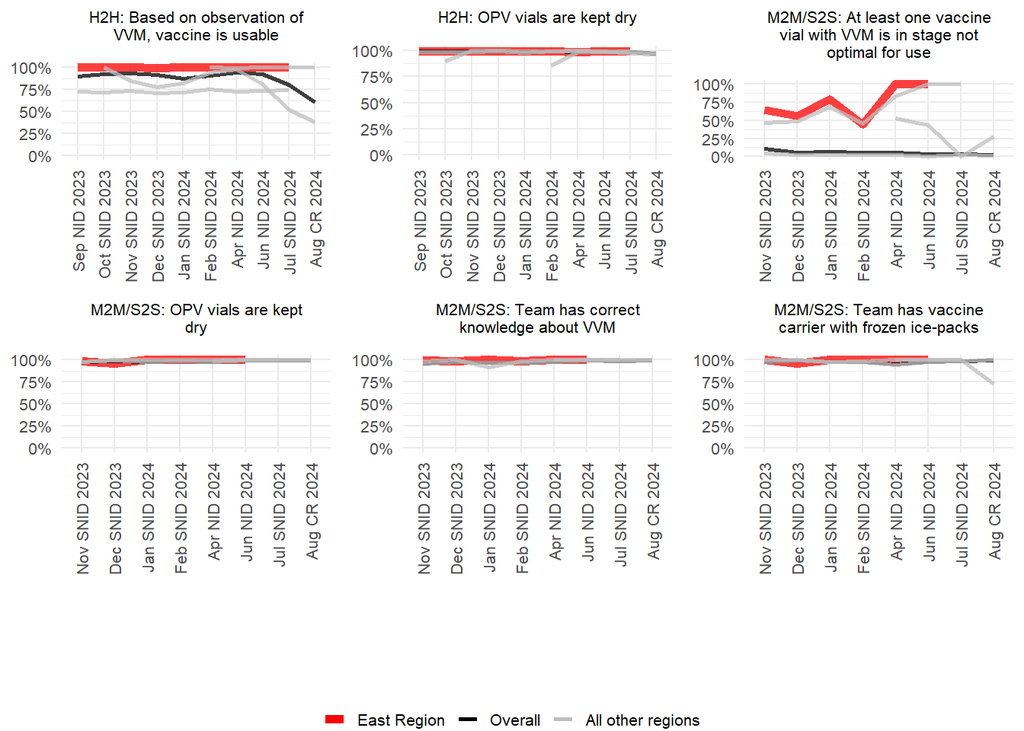

### South Region

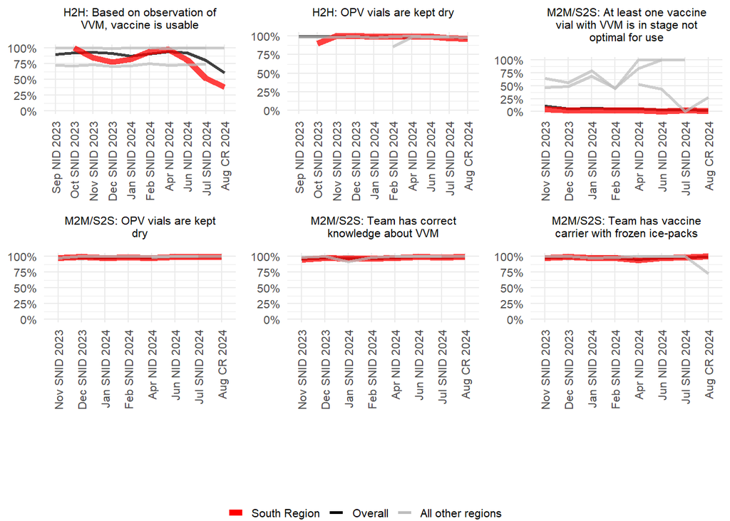

### Southeast Region

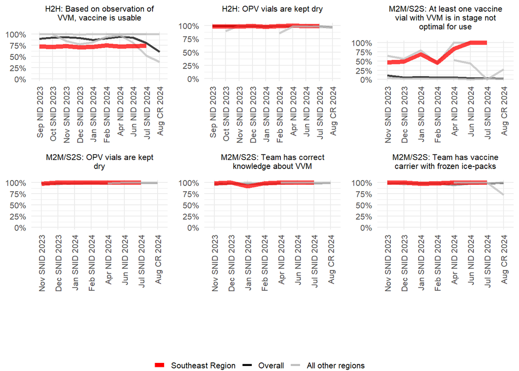

### West Region

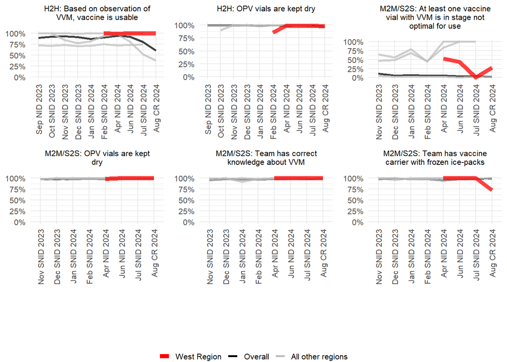